# Covid 19 status between 2019 and 2022

## Investigation Overview

In this investigation, I wanted to look at covid19 damages in 2019 and compare to the situation in end 2022. As we know, with the arrival of vaccines and heath barrier measures , the virus should be contained and normally we should have least deaths and more recovered. Let's discover what is about.

## Dataset Overview

This dataset has information on the number of affected cases, deaths and recovery from 2019 novel coronavirus.Added to data gathered in 2022.

## Distribution of Covid cases between 2019 and 2022

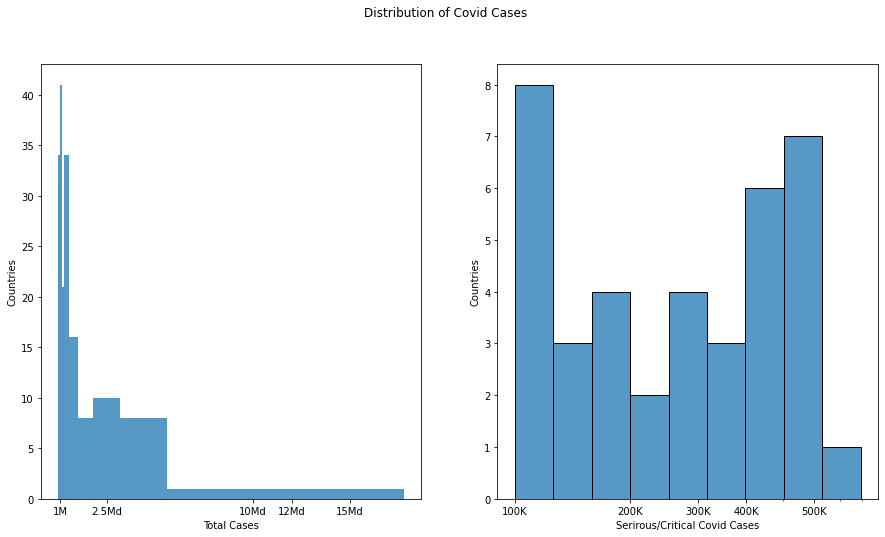

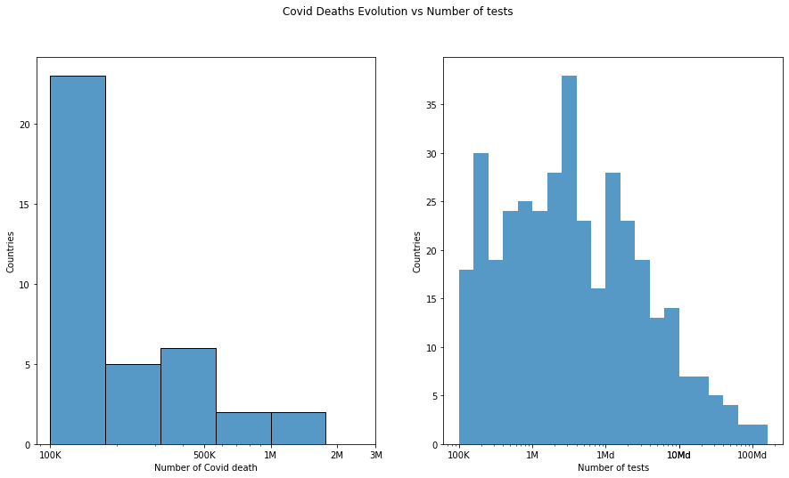

## Distribution per continent and per zone between 2019 and 2022

There is no big differences between the number of deaths in 2019 and 2022. But that a good point. That proves the efficiency of vaccines and health barrier measures. We arrived to contain the mortal side of virus.

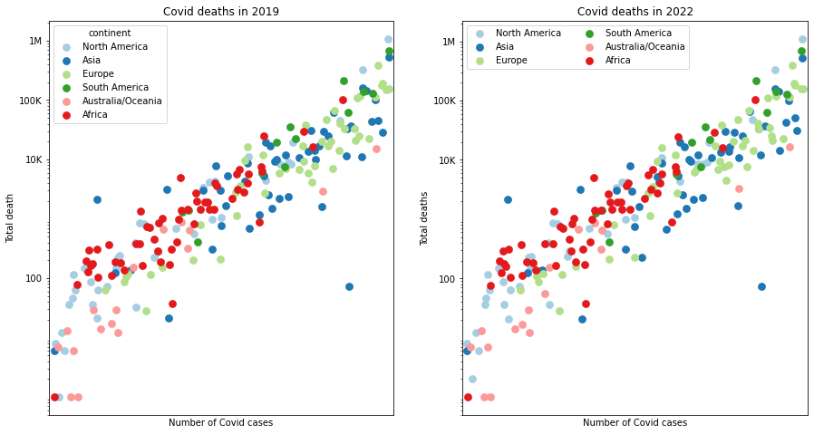

On the other hand, the number of critical cases exploded in 2022. Some dangerous and virulent variants of covid have emerged around the world, especially in many countries in Europe and Africa.

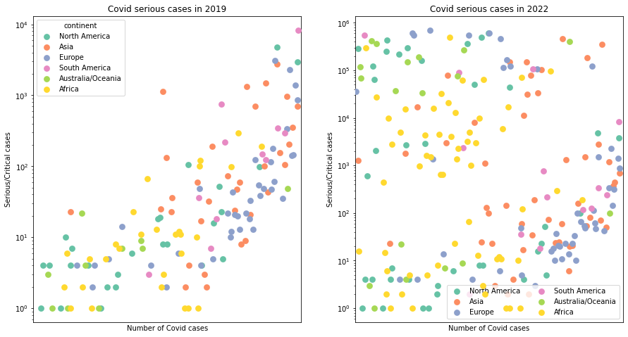

## Overview per zone

We know that currently `OMS`divided world countries into 2 kinds of zones (Orange and green). But for more visibility on improvement from Covid zones of begining , i splited into 4 groups: Green_Zone with least of 100 cases on a million of inhabitants ,Orange_Zone between 100 and 1000 cases on the million ,Red_Zone between 1000 and 100000 cases, and the worst Red_Scarlet_Zone with more than 100000 cases per million of inhabitants.

The split of countries based on total cases per million is very interesting. The famous Red scarlet Zone (>=100K cases per million inhabitants) count the highers number of death and total cases. More visible here, the number of deaths increase proportionnaly to number of cases per million inhabitants. Contrary with the number of recovered. There, we can thank the vaccine, we avoided a lot of deaths in Red scarlet zone.

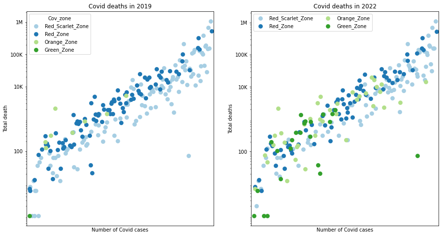

In 2022 we have more recovered especially in orange and green zone.

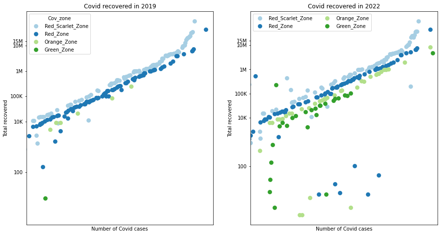

We can see that the number of critical cases has increased in the orange zone and in the red zone. Probably, the people who unfortunately could not resist died.

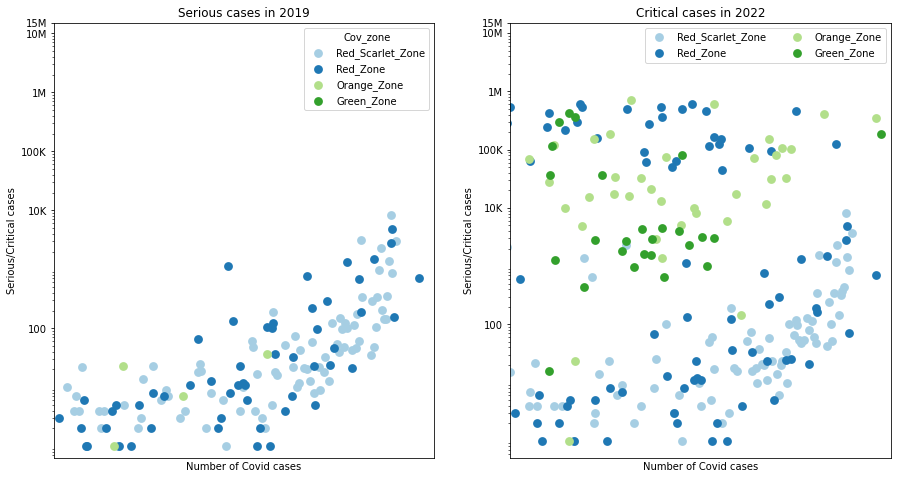